# Introduction

## About This Report

This report is for the Mid-Atlantic Fishery Management Council (MAFMC). The purpose of this report is to synthesize ecosystem information to allow the MAFMC to better meet fishery management objectives, and to update the MAFMC’s Ecosystem Approach to Fishery Management (EAFM) risk assessment. The major messages of the report are synthesized on pages 1 and 2, with highlights of 2025 ecosystem events on page 3.

The information in this report is organized into two main sections; performance measured against ecosystem-level management objectives (Table $\ref{tab:management-objectives}$), and potential risks to meeting fishery management objectives (Table $\ref{tab:management-risks}$: climate change and other ocean uses). A final section highlights notable 2025 ecosystem observations.

## Report structure

A glossary of terms[^1], detailed technical methods documentation[^2], indicator data[^3], and detailed indicator descriptions[^4] are available online. We recommend new readers first review the details of standard figure formatting (Fig. $\ref{fig:docformat}$a), categorization of fish and invertebrate species into feeding guilds (Table $\ref{tab:species-groupings}$), and definitions of ecological production units (EPUs, including the Mid-Atlantic Bight, MAB; Fig. $\ref{fig:docformat}$b) provided at the end of the document.

The two main sections contain subsections for each management objective or potential risk. Within each subsection, we first review observed trends for indicators representing each objective or risk, including the status of the most recent data year relative to a threshold (if available) or relative to the long-term average. Second, we identify potential drivers of observed trends, and synthesize results of indicators related to those drivers to outline potential implications for management. For example, if there are multiple drivers related to an indicator trend, do indicators associated with the drivers have similar trends, and can any drivers be affected by management action(s)? We emphasize that these implications are intended to represent testable hypotheses at present, rather than “answers,” because the science behind these indicators and syntheses continues to develop.

Ecosystem-scale fishery management objectives in the Mid-Atlantic Bight

| Objective categories | Indicators reported |
| --- | --- |
| Objectives: Provisioning and Cultural Services |  |
| Seafood Production | Landings; commercial total and by feeding guild; recreational harvest |
| Commercial Profits | Revenue decomposed to price and volume |
| Recreational Opportunities | Angler trips; recreational fleet diversity |
| Stability | Fishery and ecosystem volatility, adaptive capacity, and shifts from baseline |
| Social & Cultural | Community fishing engagement and social vulnerability status |
| Protected Species | Bycatch; population (adult and juvenile) numbers; mortalities |
| Potential Drivers: Supporting and Regulating Services |  |
| Management | Stock status; catch compared with catch limits |
| Biomass | Biomass or abundance by feeding guild from surveys |
| Environment | Climate and ecosystem risk indicators listed in Table 2 |

Risks to meeting fishery management objectives in the Mid-Atlantic Bight

| Risk categories | Observation indicators reported | Potential driver indicators reported |
| --- | --- | --- |
| Climate and Ecosystem Risks |  |  |
| Risks to Managing Spatially | Managed species (fish and cetacean) distribution shifts | Benthic and pelagic forage distribution; ocean temperature, changes in currents and cold pool |
| Risks to Managing Seasonally | Managed species spawning and migration timing changes | Habitat timing: Length of ocean summer, cold pool seasonal persistence |
| Risks to Setting Catch Limits | Managed species body condition and recruitment changes | Benthic and pelagic forage quality & abundance: ocean temperature & acidification |
| Other Ocean Uses Risks |  |  |
| Offshore Wind Risks | Fishery revenue and landings from wind lease areas by species and port | Wind development speed; Protected species presence and hotspots |

# Performance Relative to Fishery Management Objectives

In this section, we examine indicators related to broad, ecosystem-level fishery management objectives. We also provide hypotheses on the implications of these trends—why we are seeing them, what’s driving them, and potential or observed regime shifts or changes in ecosystem structure. Identifying multiple drivers, regime shifts, and potential changes to ecosystem structure, as well as identifying the most vulnerable resources, can help managers determine whether anything needs to be done differently to meet objectives and how to prioritize upcoming issues/risks.

## Seafood Production

### Indicators: Landings; commercial and recreational

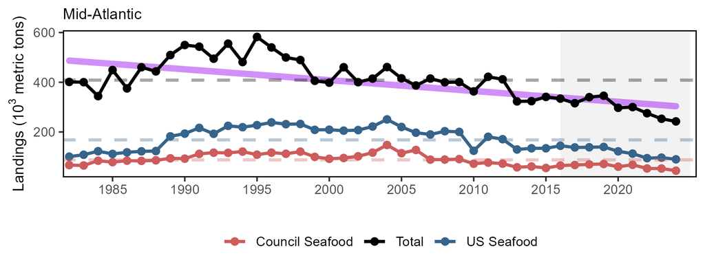

Total commercial landings (black), total U.S. seafood landings (blue), and Mid-Atlantic managed U.S. seafood landings (red), with significant decline (purple) in total landings.

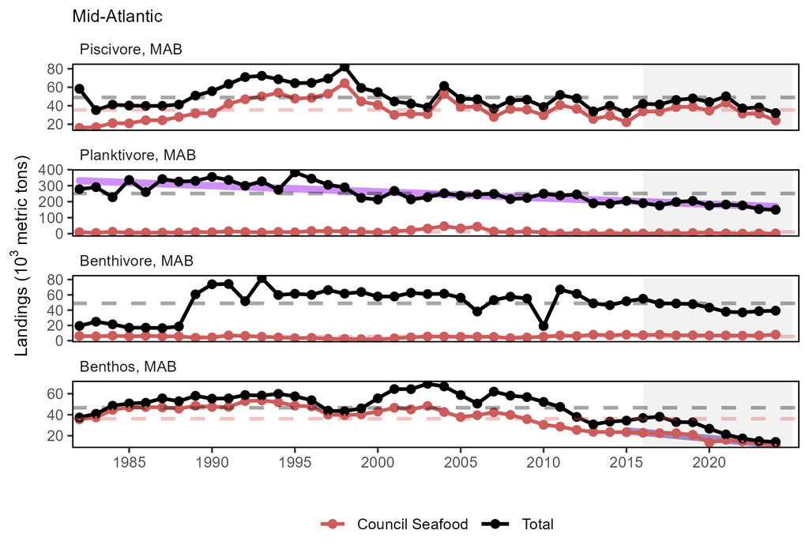

Total commercial landings in the Mid-Atlantic Bight (black) and MAFMC-managed U.S seafood landings (red) by feeding guild, with significant declines (purple) in total planktivore landings.

Mid-Atlantic ports face a moderate to high risk from environmental variability, as evaluated by the 2025 [Community Environmental Variability Risk Indicators](https://noaa-edab.github.io/catalog/community_climate_vulnerability.html) (Fig. $\ref{fig:climatevul-land}$). These indicators assess port level risk to environmental variability based on dependence on species and their respective bioenvironmental vulnerabilities as assessed by regional experts. Total Vulnerability measures how much a region’s landings (or revenue) is dependent on species that are sensitive to different climate and environmental change factors including temperature and acidification.

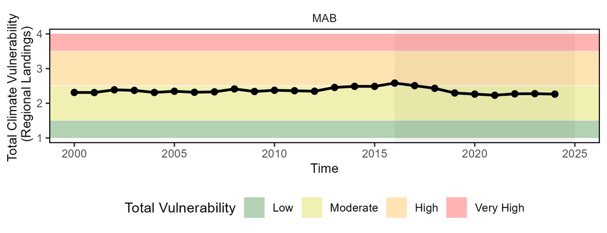

Mid-Atlantic region Total Vulnerability of commercial landings (sum of Mid-Atlantic port landings weighted by species climate vulnerability from Hare et al. 2016 and Loughran et al. 2025). Horizontal colored bars show different environmental variability risk levels.

In the Mid-Atlantic, total [recreational harvest](https://noaa-edab.github.io/catalog/recdat.html) (retained fish presumed to be eaten) shows a long-term decline with recent harvest remaining near a time series low Fig. $\ref{fig:rec-landings}$). This pattern may indicate a shift towards catch-and-release strategies as opposed to catch for harvest. [Recreational shark landings](https://noaa-edab.github.io/catalog/rec_hms.html) have generally decreased for most shark groups through 2024 (Fig $\ref{fig:rec-hms}$). The recent low in pelagic shark landings is largely driven by regulatory changes implemented in 2018, followed by the closure of the shortfin mako fishery in 2022. These actions were intended to rebuild the North Atlantic shortfin mako stock and comply with binding recommendations by the International Commission for the Conservation of Atlantic Tunas (ICCAT).

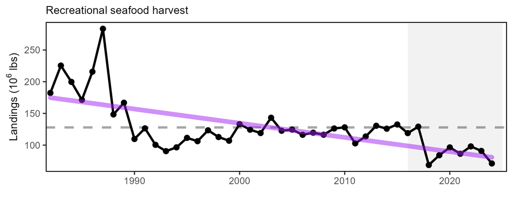

Total recreational seafood harvest (millions of pounds, black, significant decrease, purple) in the Mid-Atlantic region.

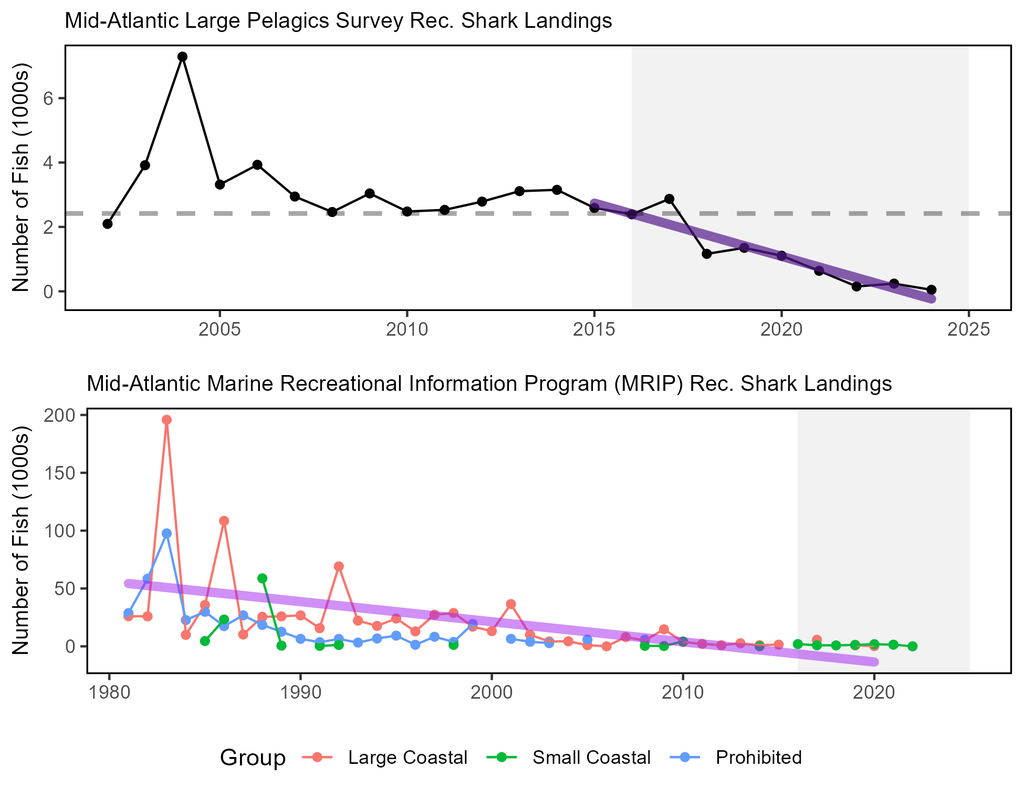

Recreational shark landings in the Mid-Atlantic region from NOAA Fisheries Large Pelagics Survey (top) and Marine Recreational Information Program (bottom) with declining trends (purple). Note that the trend line is associated with the Large Coastal group, which has had no reported MRIP landings after 2020.

[Aquaculture](https://noaa-edab.github.io/catalog/aquaculture.html?q=aqua#aquaculture) can comprise a significant proportion of seafood production in specific communities, but not all aquaculture production is included in total seafood landings above. In 2022, the Northeast region produced approximately 6,300 metric tons of aquacultured shellfish, with revenue of $133 million.

### Implications

Declining commercial landings (total and seafood) and recreational harvest can be attributed to many interacting factors, including combinations of ecosystem and stock production, management actions, market conditions, and environmental change. While we cannot evaluate all possible drivers at present, here we evaluate the extent to which stock status, management, and system biomass trends may play a role.

#### Stock Status and Catch Limits

Single species [management objectives](https://noaa-edab.github.io/catalog/stock_status.html) (1. maintaining biomass above minimum thresholds and 2. maintaining fishing mortality below overfishing limits) are being met for all but two MAFMC-managed species (golden tilefish and Atlantic mackerel) (Fig. $\ref{fig:stock-status}$). However, the status of 5 stocks is unknown (northern shortfin squid, goosefish GOM/GB, goosefish southern GB/MAB, blueline tilefish, and chub mackerel).

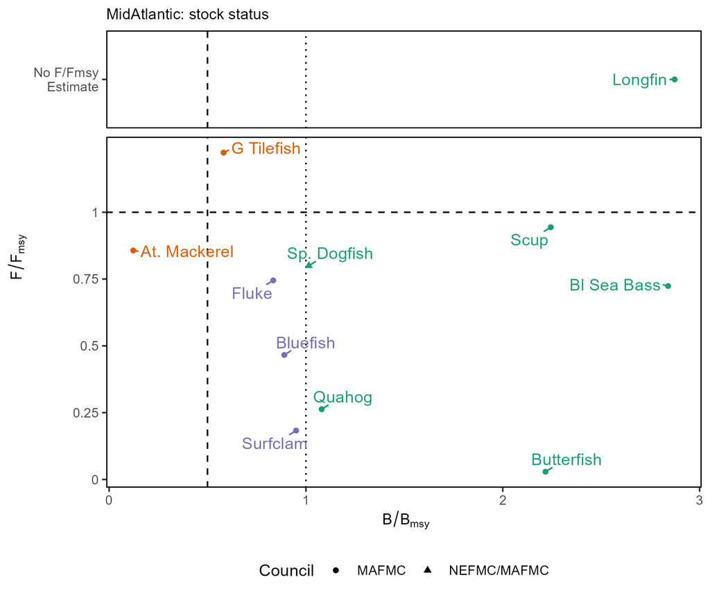

Summary of single species status for MAFMC and jointly federally managed stocks (spiny dogfish and both goosefish). The dotted vertical line is the target biomass reference point of $B_{MSY}$. The dashed lines are the management thresholds of one half $B_{MSY}$ (vertical) or $F_{MSY}$ (horizontal). Stocks with a $B/B_{MSY}$ estimate but without an $F/F_{MSY}$ estimate are denoted in a separate box plot (top). Colors denote stocks with $B/B_{MSY}$ < 0.5 or $F/F_{MSY}$>1 (orange), stocks 0.5<$B/B_{MSY}$<1 (blue), and stocks $B/B_{MSY}$>1 (green).

Stock status and associated management constraints are unlikely to be driving decreased landings for some species, including quahog, surfclam, and northern shortfin squid. Most stocks are not fully utilizing their associated ABC or ACL, which includes landings and discards (Fig. $\ref{fig:abcacl-catch}$). Quahog, surfclam, and northern shortfin squid have the largest ABC or ACLs but have low catch ratios, with less than 24% of ABC or ACL caught in 2024. All other species except chub mackerel and longfin squid have catch ratios over 80%, indicating that stock status and associated regulations are most likely constraining the landings of some species such as black sea bass, bluefish, and Atlantic mackerel. However, these management actions and regulations are enacted in response to biomass, such that less conservative regulations would not necessarily mean higher landings.

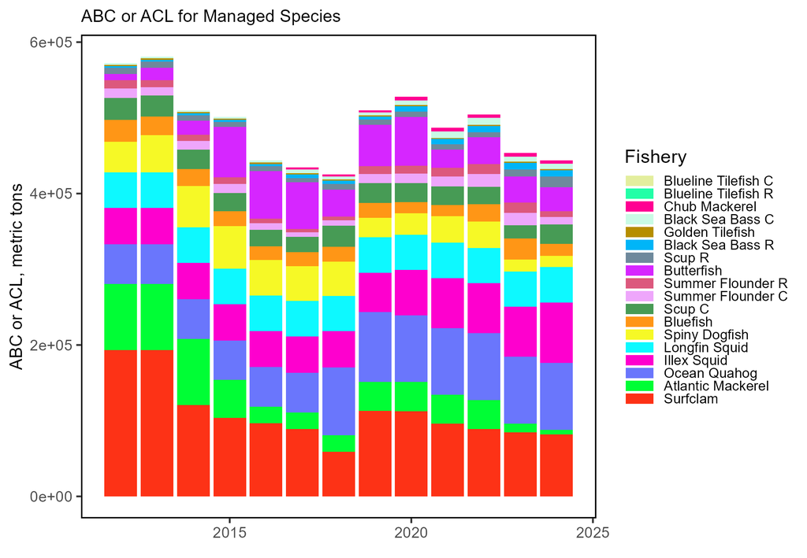

Sum of catch limits (in metric tons) across all MAFMC managed commercial (C) and recreational (R) fsheries.

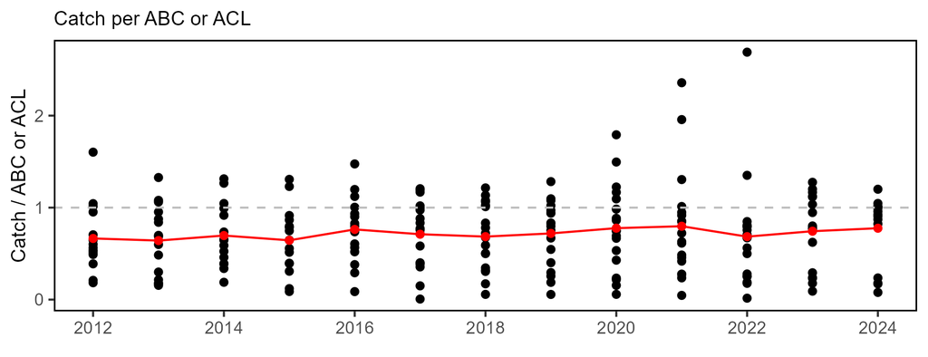

Total catch divided by ABC/ACL for MAFMC managed fisheries. High points are recreational black sea bass (2021) and scup (2022). Red line indicates the median ratio across all fisheries.

#### System Biomass

Major shifts in feeding guilds or ecosystem trophic structure are unlikely to be driving the decline in landings. [Aggregate biomass](https://noaa-edab.github.io/catalog/aggregate_biomass.html) trends derived from scientific resource surveys are mostly stable in the MAB, with long-term increases in spring piscivores, fall benthivores, and fall benthos (Fig. $\ref{fig:nefsc-biomass-mab}$). While managed species make up varying proportions of aggregate biomass, trends in landings are not mirroring shifts in the overall trophic structure of survey-sampled fish and invertebrates. Future study should investigate whether shifts in the relative abundance of targeted species may be playing a role.

#### Effect on Seafood Production

Changes in the spatial distribution of surfclams and ocean quahogs may be constraining seafood production, as this results in areas with overlapping distributions and increased mixed landings. Mixed landings are currently prohibited by regulations, which could become problematic for harvesters. However, the MAFMC submitted an amendment in August 2025 to NOAA Fisheries to allow mixed surfclam and quahog trips; as of February 2026, the amendment remains under review by NOAA.

The recent decline in recreational seafood harvest is likely associated with a combination of targeted management actions, shifting social behaviors, and data collection changes. The decline in recreational shark landings can be attributed to management actions intended to reduce fishing mortality on mako sharks. The lower than average landings since 2018 for species other than sharks could be driven by either changes in fishing behavior or a change in NOAA Fisheries’ Marine Recreational Information Program survey methodology in 2018. The decline in recreational seafood harvest may also be linked to decreases in sustenance fishing.

- **Unprecedented Climate Shifts**: Global ocean temperatures have reached record highs (see 2025 Highlights section) and the Northeast US shelf has experienced long-term warming.
- **Distribution Shifts**: Stocks are shifting towards the northeast and into deeper waters throughout the Northeast US Large Marine Ecosystem (see Climate Risks section).
- **Ecosystem production**: Changes in ecosystem composition and biological production are impacting the stability of the ecosystem and pose risks to setting catch limits.
- **Community Risks**: Changes in the ecosystem can affect the stability of fisheries and pose risks to fishing communities.

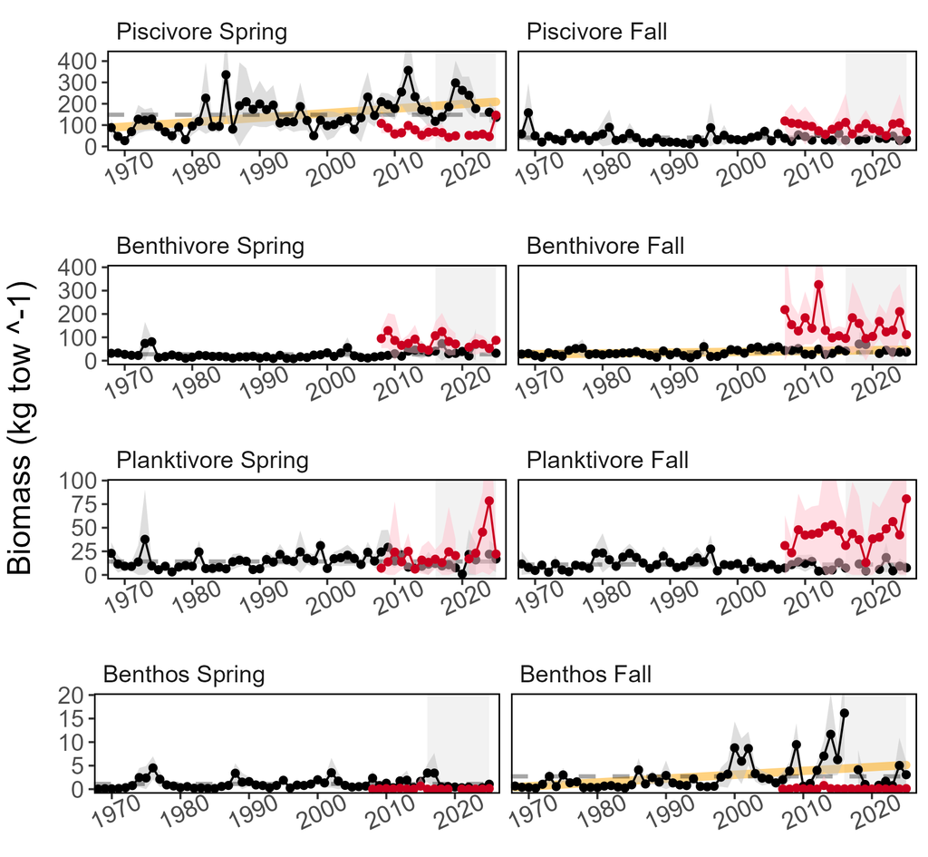

Spring (left) and fall (right) surveyed biomass in the Mid-Atlantic Bight. Data from the NEFSC Bottom Trawl Survey are shown in black, with the nearshore NEAMAP survey shown in red. Significant increases (orange lines) are present for spring piscivore, fall benthivore, and fall benthos biomass. The shaded area around each annual mean represents 2 standard deviations from the mean.

## Commercial Profits

### Indicators: revenue & net revenue

Total [commercial revenue](https://noaa-edab.github.io/catalog/comdat.html) and MAFMC managed species revenue (2024 USD) within the Mid-Atlantic Bight have declined over the past 20 years. In 2024, total revenue and MAFMC managed species revenue were both near an all-time low (Fig. $\ref{fig:comm-revenue}$).

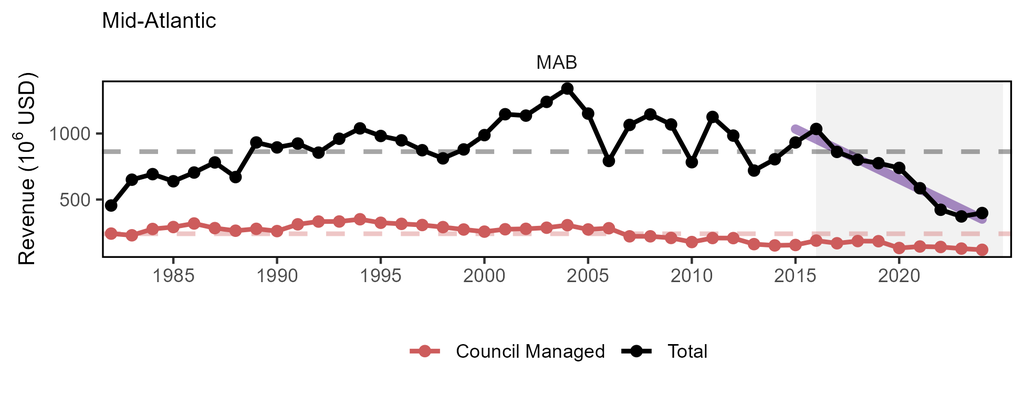

Commercial revenue (2024 USD) through 2024 for the Mid-Atlantic region: total (black) and from MAFMC managed species (red). Dashed lines represent the long-term annual mean. A significant decrease is present for total revenue (purple).

Revenue earned by harvesting resources is a function of both the quantity landed of each species and the prices paid for landings. Therefore, total revenue patterns can be driven by harvest levels, the mix of species landed, price changes, or a combination of these. The [Bennet Indicator](https://noaa-edab.github.io/catalog/bennet.html) (BI) decomposes revenue change into two parts, one driven by changing quantities (volumes), and a second driven by changing prices. All changes are in relation to a base year (1982). The 1982 base year was selected because that is the first year the relevant data is available and it allows for an extended period of time to evaluate market trends and dynamics. The BI results demonstrate that relatively high revenues in 2014-2016 were equally due to higher landings and prices (Fig. $\ref{fig:bennet}$). In more recent years, both landings and prices have been closer to values from the reference year (1982). Low prices coupled with low volumes landed, led to low revenue in 2024. Recent lower than average revenues are partially due to declining prices of benthivores. Benthos prices increased from 2023, but overall benthos revenue remained low due to low volumes landed (Fig. $\ref{fig:bennet-all}$).

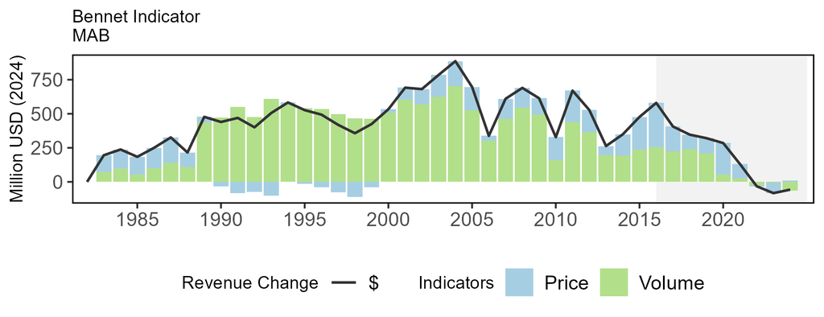

Revenue change from 1982 values in 2024 dollars (black); Price (blue), and Volume Indicators (green) for total commercial landings in the Mid-Atlantic Bight.

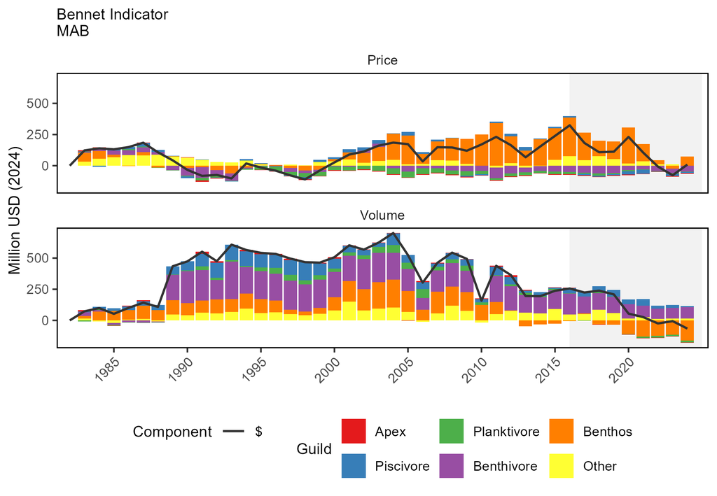

Total price (top) and volume (bottom) indicators in 2024 dollars (black) for commercial landings, and individual guild contributions to each indicator, in the Mid-Atlantic Bight.

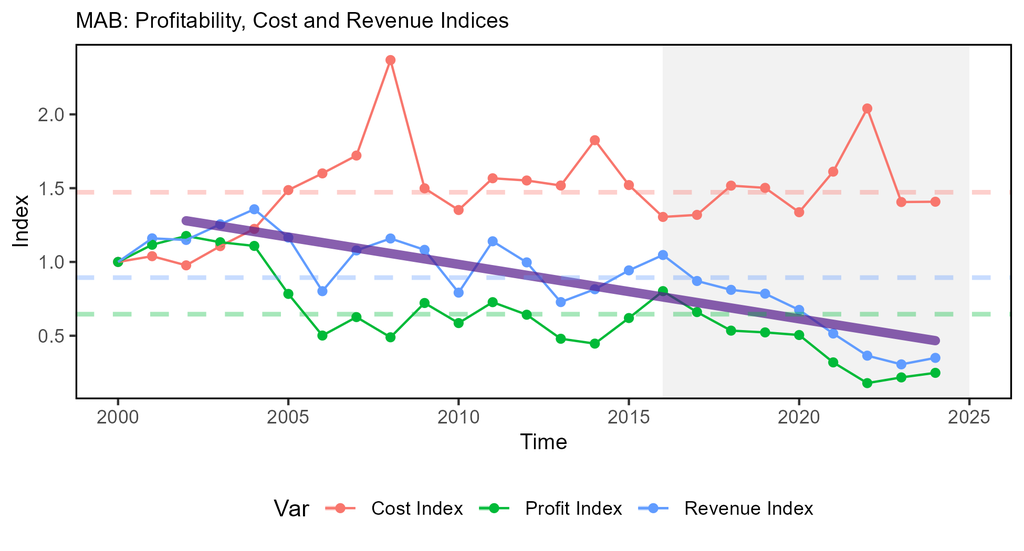

Profitability indices for Mid Atlantic federally managed species: cost index (red), profit index (green), and revenue index (blue). Dashed lines represent the long-term annual means for each index. Long-term declining trend (purple) associated with revenue index.

This year, we present new indicators of [profitability](https://noaa-edab.github.io/catalog/comdat_profit.html): indices of cost, revenue, and profit based on trips catching federally-managed species. In this index, costs pertain to trip costs, excluding labor, estimated for all federal trips in the region. The profit indicator is net-revenue, determined as the difference between trip revenue and trip costs. Trips were spatially allocated to compile regional indices. Indices are presented as values relative to 2000, the first year in the dataset. In the Mid-Atlantic, costs have fluctuated, but overall remain near the time series mean, despite some high costs in 2022, 2014 and 2008. Revenue, however, has declined steadily since 2019 and is driving an overall decline in profits (Fig. $\ref{fig:comdat-profit}$).

For Mid-Atlantic ports, [total vulnerability](https://noaa-edab.github.io/catalog/community_climate_vulnerability.html) of revenue is high for the entire time series (2000-2024), with no long-term trend. This suggests that Mid-Atlantic port commercial fishing revenue is highly reliant on climate-sensitive species for the entire time period assessed (Fig. $\ref{fig:climatevul-rev}$).

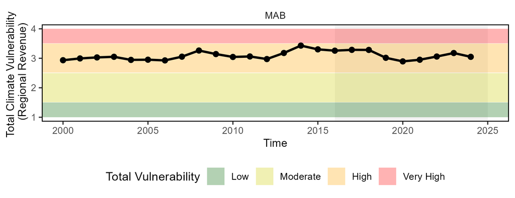

Mid-Atlantic region total climate vulnerability of commercial revenue (sum of Mid-Atlantic port revenue weighted by species climate vulnerability from Hare et al. 2016). Horizontal colored bars show different climate risk levels.

## Recreational Opportunities

### Indicators: Angler trips, fleet diversity

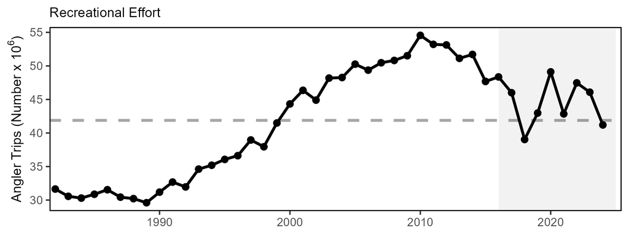

Recreational effort (total number of recreational angler trips from 1980-2024) in the Mid-Atlantic. Derived from MRIP’s Effort Time Series Query.

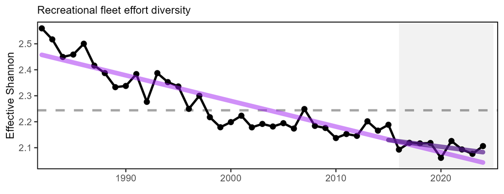

Recreational fleet effort diversity from 1980-2024 in the Mid-Atlantic, with significant decrease in long-term (light purple) and short-term (dark purple) trends.

### Implications

A contraction of party/charter trips (dropping from 2.2% of trips in 2021 to 1.3% in 2023) is the primary driver of the downward effort diversity trend, alongside a shift toward shorebased angling, which now makes up 60% of trips. Private boat effort has remained consistent to 2022 values.

Managers should consider the differing species and fish sizes for shore-based and vessel-based anglers. Some species use inshore regions as nursery grounds while other species only come inshore as adults. Many states have developed shore-based regulations where the minimum size is lower than in other areas and sectors to maintain opportunities in the shore angling sector. The MAFMC is currently considering recreational sector separation which might establish different options for managing the for-hire sector from other modes.

## Social and Community Risks

Fisheries management seeks to provide for sustained participation of fishing communities and to avoid adverse economic impacts to fishing communities. A new [composite indicator](https://noaa-edab.github.io/catalog/engagement.html?q=engage#introduction-to-indicator-72) (Port Commercial Fishing Activity Indicator or PCFA) utilizes NOAA data on dealers, fish landings, and commercial permits to explore trends in commercial fishing activity over time in top ports. This information can be used to understand how changes in fish stocks, regulations, and other social-ecological factors may have disparately impacted ports throughout the Greater Atlantic region.

The recreational engagement index has not been updated from last year and will be updated with similar methods as PCFAI in future reports. The recreational [engagement](https://noaa-edab.github.io/catalog/engagement.html) index demonstrates participation levels in recreational fishing in a given community relative to other coastal communities in a region.

The Community Social Vulnerability Indicators (CSVI) utilize U.S. Census American Community Survey data to describe social characteristics at the municipality level (i.e., not just the fishing community) and provide context for the municipalities utilized by commercial fishing industry participants. Fishing industry participants that live in and/or utilize resources in municipalities with relatively concerning socio-demographic conditions may be more vulnerable to changes. The personal disruption index addresses factors that reduce adaptability to change such as unemployment or educational level. The poverty index is a composite index that indicates a community’s financial standing relative to other communities. The population composition index characterizes groups within communities that may be more vulnerable to change. CSVI information for communities highlighted in the PCFA and recreational engagement index have been updated with the most recent census data.

Coastal fishing communities worldwide have or are likely to experience social, economic, and cultural impacts from climate change, both negative (e.g., loss of infrastructure, fish stock decline) and positive (e.g., increased abundance of valuable species). Changes in marine fisheries as a consequence of climate change will require adaptation by coastal fishing communities and fisheries managers alike. The Community Environmental Variability Risk Indicators (CEVRI) were developed to help examine trends in risk related to dependence on species vulnerable to climate and environmental changes.

### Indicators: Port Commercial Fishing Activity and Community Social Vulnerability

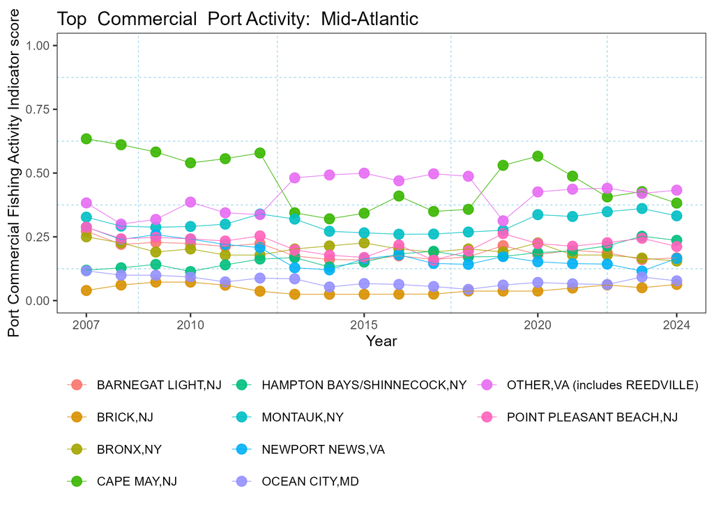

Port Commercial Fishing Activity Indicator scores over time in the top 10 commercially active fishing ports in the Mid-Atlantic.

Community Vulnerability factors for the municipalities housing the top 10 commercially active Mid-Atlantic Ports

| Community | Personal Disruption | Population Composition | Poverty |
| --- | --- | --- | --- |
| Bronx, NY | high | high | high |
| Newport News, VA | med | med high | med |
| Hampton Bays/Shinnecock, NY | low | med high | low |
| Ocean City, MD | med | low | low |
| Barnegat Light, NJ | low | low | low |
| Cape May, NJ | low | low | low |
| Point Pleasant Beach, NJ | low | low | low |
| Brick, NJ | low | low | low |
| Montauk, NY | low | low | low |
| Reedville, VA | low | low | low |

Of those included in the top-ranked recreational communities, both Morehead City, NC and Virginia Beach, VA had medium or higher ranks for at least one socio-demographic indicator (Table $\ref{tab:recvultab}$). This suggests that future changes to recreational fishing conditions may disproportionately impact these places.

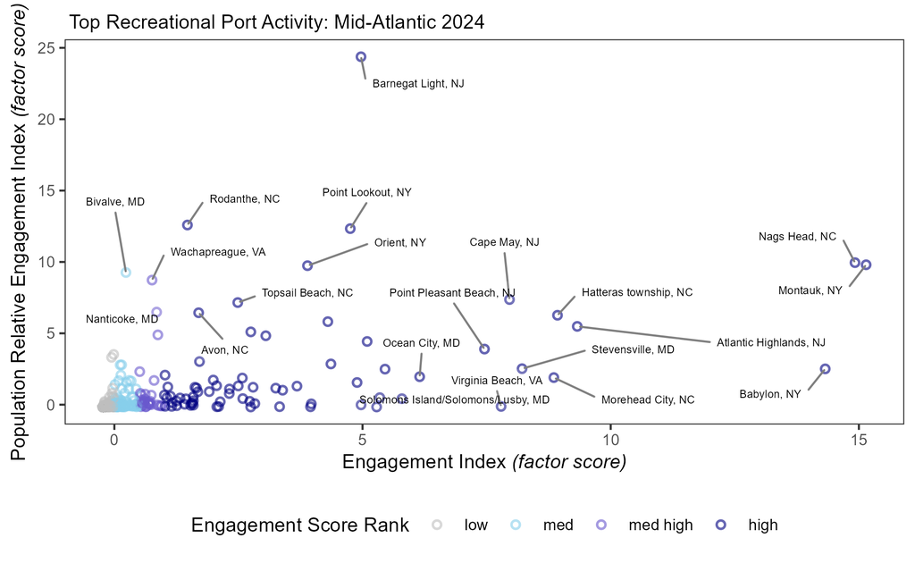

Recreational engagement and population relative engagement with labels for the top recreationally engaged fishing communities in the Mid-Atlantic (last updated 2024).

Community Vulnerability factors for the top 10 recreationally engaged Mid-Atlantic Ports

| Community | Personal Disruption | Population Composition | Poverty |
| --- | --- | --- | --- |
| Morehead City, NC | med | low | med high |
| Virginia Beach, VA | low | med | low |
| Stevensville, MD | low | low | low |
| Nags Head, NC | low | low | low |
| Hatteras Township, NC | low | low | low |
| Atlantic Highlands, NJ | low | low | low |
| Cape May, NJ | low | low | low |
| Point Pleasant Beach, NJ | low | low | low |
| Babylon, NY | low | low | low |
| Montauk, NY | low | low | low |

### Indicators: Community Environmental Variability Risk in the Mid-Atlantic

[Community Environmental Variability Risk Indicators](https://noaa-edab.github.io/catalog/community_climate_vulnerability.html) (CEVRI) measure risk by linking commercial landings and revenue to specific climate sensitivity factors, including temperature, ocean acidification, and stock status using the Climate Vulnerability Assessment (CVA) scores. These indicators calculate total sensitivity and vulnerability scores based on a community’s dependence on species vulnerable to climate change. Risk scores range from low (1) to high (4), increasing as a community relies more heavily on species at higher risk from environmental shifts.

While long-term risk trends across the Mid-Atlantic remain stable, most individual fishing communities currently rank as high or very high risk. This high ranking demonstrates that a majority of regional communities depend on species that are highly vulnerable to changing ocean conditions for their commercial revenue. Strategies for management should account for this widespread reliance on climate-sensitive stocks.

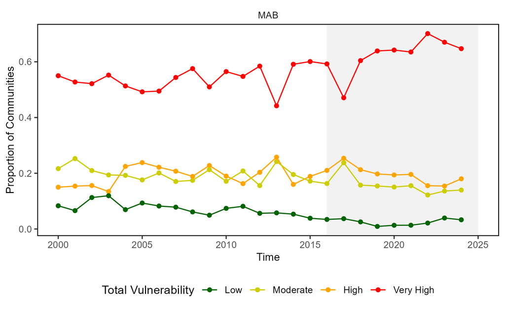

Proportion of Mid-Atlantic communities at each revenue climate vulnerability level over time. Total climate vulnerability ranges from low (green), moderate (yellow), high (orange), to very high (red).

### Implications

A range of socioeconomic and environmental variability risk concerns are found throughout Mid-Atlantic fishing communities, and the CSVI and CEVRI indicate socio-demographic concerns in the most highly active commercial Mid-Atlantic fishing ports. Fishing industry participants that utilize more vulnerable ports may be at increased relative risk to changes in fishing patterns due to regulations and/or ecosystem changes.

A majority of Mid-Atlantic communities have high to very high total environmental variability risk based on revenue. Coastal fishing communities are greatly affected by environmental change, both because of their physical location and because of their frequent social, cultural, and economic dependence on fishing. These impacts are expected to become more pressing as changes become more extensive. Changes in [ocean temperature](https://noaa-edab.github.io/catalog/bottom_temp_insitu.html) and [acidification](https://noaa-edab.github.io/catalog/ocean_acidification.html) affecting marine life have the potential to directly impact fisheries and fishery dependent livelihoods.

## Protected Species

Fishery management objectives for protected species generally focus on reducing threats and on habitat conservation/restoration. Specific actions include managing bycatch to remain below potential biological removal (PBR) thresholds, recovering endangered populations, and monitoring unusual mortality events (UMEs). Protected species include marine mammals protected under the Marine Mammal Protection Act, endangered and threatened species protected under the Endangered Species Act, and migratory birds protected under the Migratory Bird Treaty Act. In the Northeast U.S., endangered/threatened species include Atlantic salmon, Atlantic and shortnose sturgeon, all sea turtle species, giant manta ray, oceanic whitetip shark, and five baleen whales. Here we report on performance relative to these objectives, as well as how observed and predicted ecosystem changes in the Northeast U.S may impact these objectives in the future.

### Indicators: bycatch, population (adult and juvenile) numbers, mortalities

The management objective for [harbor porpoise](https://noaa-edab.github.io/catalog/harborporpoise.html) has been met, as the average index (Fig. $\ref{fig:harborporpoise}$) remains below the current PBR threshold.

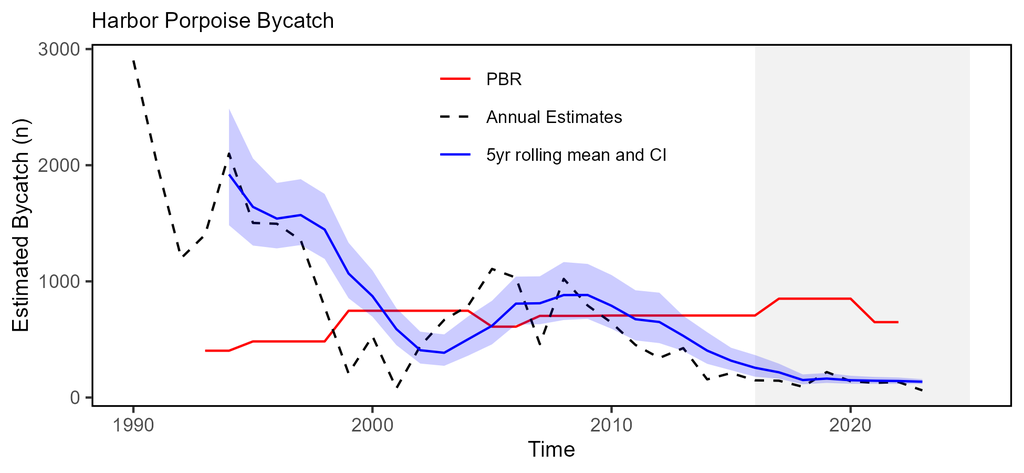

Harbor porpoise average bycatch estimate for Mid-Atlantic and New England gillnet fisheries (blue, confidence interval shaded) and the potential biological removal (red). The dashed line (black) represents the annual estimated bycatch.

The annual estimate for gray seal bycatch, most of which occurs in New England, has generally declined since 2019, in part driven by declining gillnet landings. Although, post-2019 estimates have greater uncertainty stemming from low observer coverage. The U.S. and Canadian range-wide PBR for [gray seals](https://noaa-edab.github.io/catalog/grayseal.html) is 12,052. Despite the PBR for the portion of this stock in U.S. waters being reduced to 756 animals bycatch (Fig. $\ref{fig:grayseal}$), but due to incomplete data on anthropogenic mortality and serious injury, bycatch for this stock is still considered unlikely to exceed the range-wide PBR. Thus the bycatch management objective gray seals has been met.

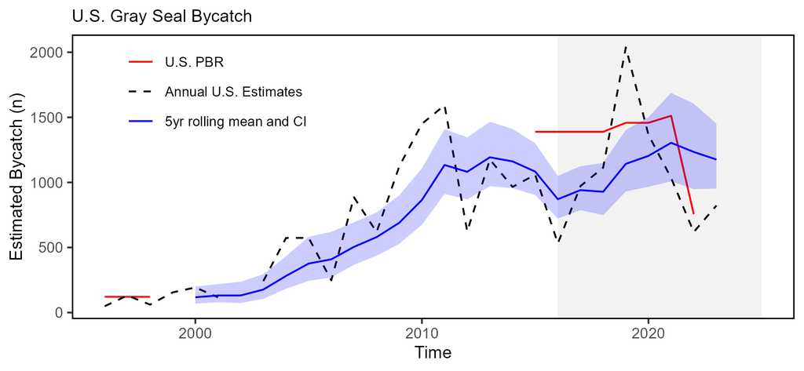

Gray seal five-year average bycatch estimate for New England and Mid-Atlantic U.S. gillnet fisheries (blue, with confidence interval shaded) and the potential U.S. biological removal (red). The range-wide PBR, including both U.S. and Canadian portions of the population, is 12,052 in the draft 2024 SAR. The dashed line (black) represents the annual estimated bycatch.

The [North Atlantic right whale population](https://noaa-edab.github.io/catalog/narw.html) was on a recovery trajectory until 2010, but has since declined (Fig. $\ref{fig:narw-abundance}$), slowing since 2020. The right whale population continues to experience annual mortalities above recovery thresholds. Reduced survival rates of adult females lead to diverging abundance trends between sexes. It is estimated that there are approximately 70 adult females remaining in the population.

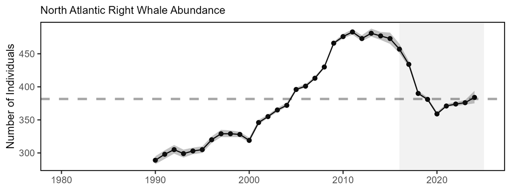

Estimated North Atlantic right whale abundance on the Northeast Shelf. 95% confidence interval shaded in gray around the line. Analysis is based on methods by Pace, Corkeron, and Kraus (2017), as documented most recently by Linden (2025).

North Atlantic right whale [calf counts](https://noaa-edab.github.io/catalog/narw.html) have generally declined after 2009 to the point of having zero new calves observed in 2018 (Fig. $\ref{fig:NARW-calf-abundance}$). However, since 2020, calf births have been closer to the long-term average, with 11 calves born in 2025.

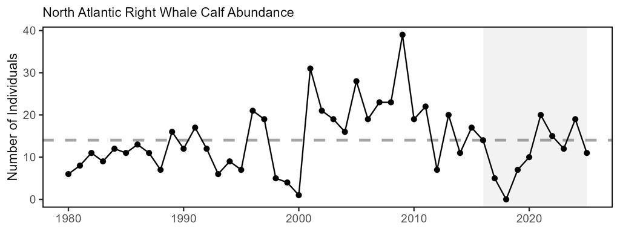

Number of North Atlantic right whale calf births since 1980. Calf birth estimates are available in Linden (2025).

Human interaction from entanglements or vessel strikes remains the primary cause of death in an ongoing North Atlantic right whale Unusual Mortality Event (UME) since 2017. As of 5 January 2026, the UME includes 168 individual whales: 41 confirmed mortalities (19 US; 22 Canada), 40 serious injuries, and 87 sublethal injuries or illnesses. Recent research suggests that many mortalities go unobserved and the true number of mortalities are about three times the count of the observed mortalities.

There is an ongoing UME for humpback whales (2016-present) and Atlantic minke whales (2018-present); suspected causes include human interactions. A UME for Northeast pinnipeds that began in 2018 for infectious disease is non-active pending closure as of February 2026.

### Implications

Bycatch management measures have been implemented to maintain bycatch below PBR thresholds. The downward trend in harbor porpoise bycatch could also be due to a decrease in harbor porpoise abundance in U.S. waters, reducing their overlap with fisheries, and a decrease in gillnet effort. The increasing trend in 5-year average gray seal bycatch may be related to an increase in the gray seal population ([U.S. pup counts](https://noaa-edab.github.io/catalog/seal_pups.html)), supported by the dramatic rise over the last three decades in observed numbers of gray seal pups born at U.S. breeding sites plus an increase in adult seals at the breeding sites, some of which are supplemented by Canadian adults.

Strong evidence exists to suggest that interactions between right whales and both the fixed gear fisheries in the U.S. and Canada and vessel strikes in the U.S. are contributing substantially to the decline of the species. Further, right whale distribution has changed since 2010. [Recent research](https://noaa-edab.github.io/catalog/narw.html) suggests that recent climate driven changes in ocean circulation have resulted in right whale distribution changes driven by increased warm water influx through the Northeast Channel, which has reduced the [primary right whale prey](https://noaa-edab.github.io/catalog/preyfield_energy.html) (the copepod *Calanus finmarchicus*) in the central and eastern portions of the Gulf of Maine. Additional potential stressors include offshore wind development, which overlaps with important habitat areas used year-round by right whales, including mother and calf migration corridors and foraging habitat. Additional information can be found in the offshore wind risks section.

The UMEs are under investigation and are likely the result of multiple drivers. For all large whale UMEs, human interaction appears to have contributed to increased mortalities, although investigations are not complete.

A climate vulnerability assessment (Lettrich et al. 2023) is published for Atlantic and Gulf marine mammal populations.

## Stability

This year, we have updated the definition of stability for fisheries and ecosystems as a measure of how consistent we expect the system to be over time. Three components of stability are considered for the purpose of this report: volatility, adaptive capacity, and a shift from baseline. Volatility is a measure of predictability, where volatile conditions indicate that future years are more likely to be different than the recent past. Adaptive capacity refers to a system’s ability to respond to changes without fundamentally changing its composition or structure. A shift from baseline refers to a systemic shift in a system towards a new status, where prior conditions may no longer be the norm. Measures of volatility are currently being developed. Therefore, we assess fisheries and ecosystem stability as “stable” if there is no notable change in adaptive capacity or shifts from a historic baseline, and “not stable” if there are changes in either of these components.

#### Fishery Stability

Indicators suggest that Mid-Atlantic fisheries have broadly shifted from the historic baseline. Commercial fishery fleet count has declined while fleet revenue diversity has been stable over time in the MAB, but current values are above the long-term average (Fig. $\ref{fig:comm-div-fleet}$). [Revenue per unit effort](https://noaa-edab.github.io/catalog/effective_sweptarea.html) remains steady or increasing over time for most gear types, indicating financial viability of current fishing operations. This indicates that the commercial fleet composition has changed, but the portfolio of species targeted is similar over time (Fig. $\ref{fig:commercial-div-species-div}$). Target species such as Atlantic mackerel and quahog have had reduced catch limits in recent years, resulting in reduced landings in these fisheries, and a decline in scallop catch within the MAB has severely reduced the total revenue generated in the region. Because non-MAFMC managed landings and revenue have declined, a larger share of the regional landings and revenue come from Council-managed fisheries.

The [Crew Survey](https://noaa-edab.github.io/catalog/crew_survey.html) shows that specific aspects pertaining to sustainability and resilience of the fishing lifestyle are declining: predictability of earnings, the amount of time away from home, the physical fatigue of the job, and the personal health impacts have all been cited as dissatisfaction rates increase. Overall job satisfaction remains relatively stable over time, but unveils vulnerability as additional survey results show an aging population, particularly an increase in the 55+ crew cohort, and fewer individuals entering the fishery. This suggests a reduced capacity for Mid-Atlantic commercial fisheries to adapt to future uncertainties and change. New [Communities at Sea](https://noaa-edab.github.io/catalog/communities_at_sea.html) indicators that assess fishing communities’ ability to adapt to change are in development and will provide additional fishing industry indicators in future reports.

Despite reduced [recreational landings](https://noaa-edab.github.io/catalog/recdat.html) (Fig. $\ref{fig:rec-landings}$), the number of recreational trips is near average (Fig. $\ref{fig:rec-op}$), suggesting a shift to catch-and-release fishing. Billfish (i.e., white marlin) catch-and-release was especially high, possibly due to shifting effort due to the closure of the recreational bluefin tuna fishery in August 2025. Shark and large sport fish regulations, the right environmental conditions, and other circumstances may also contribute to reduced recreational landings. As noted above, [recreational fleet effort diversity](https://noaa-edab.github.io/catalog/recdat.html) is declining (Fig. $\ref{fig:rec-div}$), suggesting a shift in recreational fishing opportunities. The Mid-Atlantic has experienced a contraction of the party and charter sectors, with more recreational angling occurring from shore. Recreational species catch diversity has no long-term trend and has been at or above the long-term average since 2016 (Fig. $\ref{fig:recdat-div-catch}$), indicating that anglers continue to catch a mix of species.

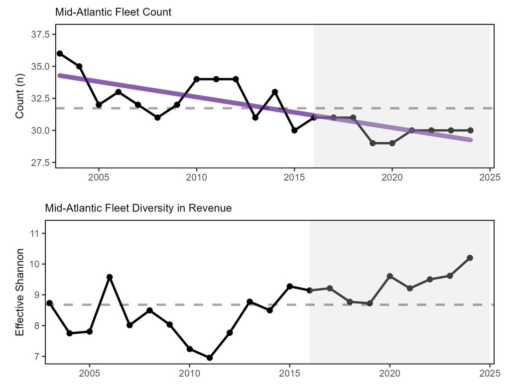

Commercial fleet count (top) and fleet diversity in revenue (bottom) in the Mid-Atlantic with significant decline in fleet count (purple line).

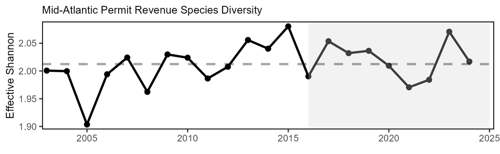

Species revenue diversity (permit-level species effective Shannon index) in the Mid Atlantic.

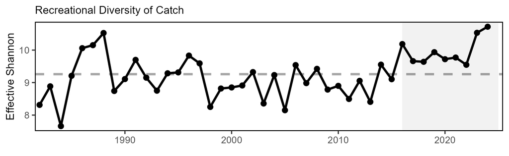

Diversity of recreational catch in the Mid Atlantic. Derived from MRIP’s Catch Time Series Query.

#### Ecological Stability

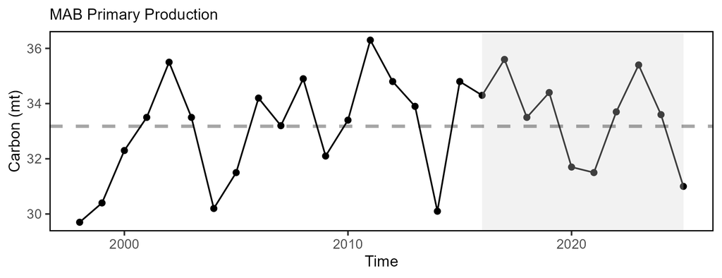

Total areal annual primary production for the MAB. The dashed line represents the long-term (1998-2025) annual mean.

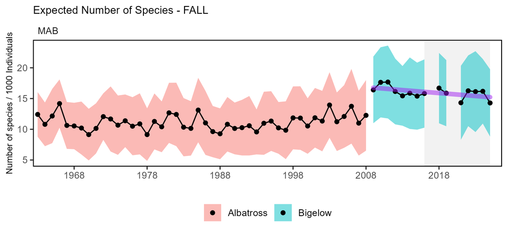

Adult fish diversity in the Mid-Atlantic Bight, based on expected number of species in a standard number of individuals. Results from survey vessels Albatross (red) and Bigelow (blue) are reported separately due to catchability differences. A significant decrease is present in the Bigelow time series (purple).

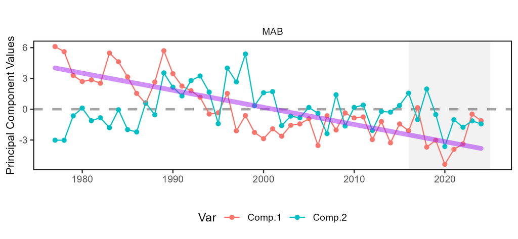

Principal component analysis of zooplankton community composition in the MAB. Lines show the first two principal components (colors). The declining trendline (purple) is associated with the first principal component. This trend is driven by an increasing abundance of sea butterflies, hyperiid amphipods, echinoderm larvae, arrow worms, and the copepod Calanus minor, and a decreasing abundance of the copepods Pseudocalanus spp., Centropages hamatus, Acartia spp., and Temora longicornis.

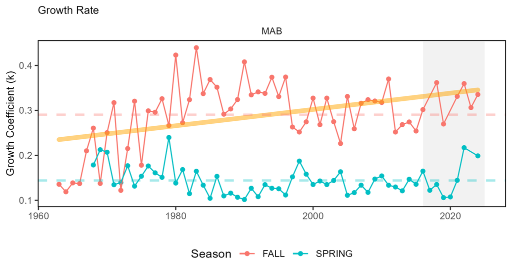

Fish community functional traits (growth rate) in the Mid Atlantic Bight based on Fall (red) and Spring (blue) survey data with a significant increase (orange) present in the fall. Dashed lines represent the long-term annual mean for each survey.

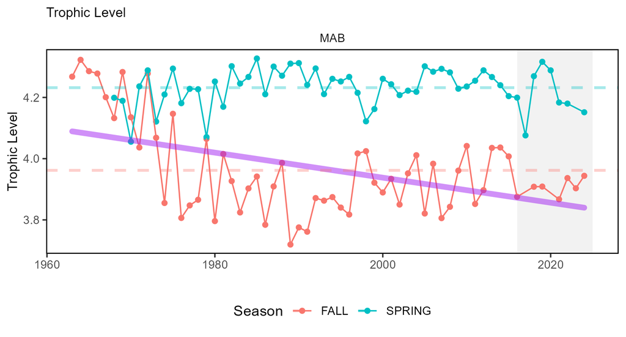

Fish community functional traits (trophic level) in the Mid Atlantic Bight based on Fall (red) and Spring (blue) survey data with a significant decrease (purple) present in the fall. Dashed lines represent the long-term annual mean for each survey.